# RSF: Cross-Validation and Mapping

Riley & Nate & Elie

2023-09-20

**Goals:** to perform cross-validation as per Boyce et al. 2002 and mapping as per recommendations of Morris et al. 2016.

# 1. Load data

```r
require(sf)
require(terra)
```

Rasters are landcover and distance to coastline

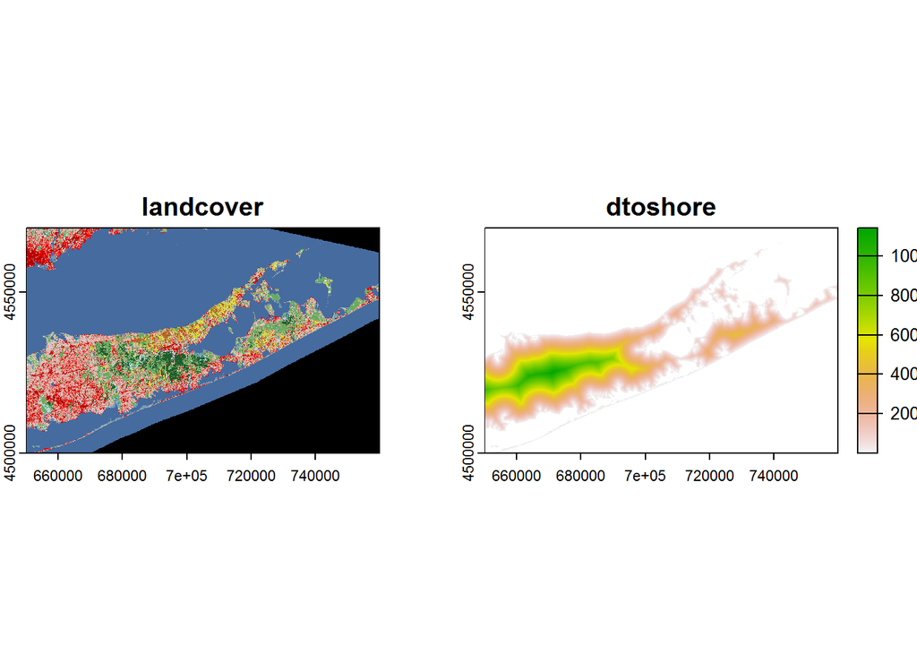

```r
require(terra)
duck.landcover <- rast("data/Landcover.tif")
dtoshore <- rast("data/DtoShore.tif")
habitat <- c(duck.landcover,dtoshore)
plot(habitat)
```

RSF data has been agonizingly prepped by Riley & Nate & Elie

```r
load("data/ducks_rsf.rda")
```

Object is called:

```r
ducks.rsf %>% head
```

```
##   landcover            datetime        X       Y    dtoshore Used
## 1        11 2022-03-19 21:06:00 723909.3 4535923 2558.544922 TRUE
## 2        11 2022-02-24 04:54:00 711566.1 4541377  643.748535 TRUE
## 3        11 2022-03-21 09:38:00 725764.8 4532189  634.593933 TRUE
## 4        11 2022-03-18 20:10:00 713458.5 4538297  324.777222 TRUE
## 5        11 2022-03-14 06:57:00 701860.4 4532079    9.641994 TRUE
## 6        11 2022-03-20 21:21:00 711652.0 4541472  737.269897 TRUE
##   landcover.name
## 1     Open Water
## 2     Open Water
## 3     Open Water
## 4     Open Water
## 5     Open Water
## 6     Open Water
```

Null set is points inside Suffolk county, which is here:

```r
load("data/Suffolk.rda")
```

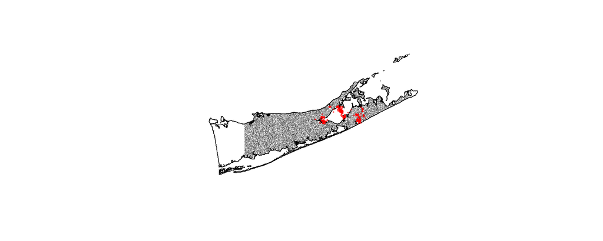

```r
plot(st_geometry(Suffolk))
with(ducks.rsf[ducks.rsf$Used == 0,],
     points(X,Y, pch = 19, cex = 0.1, col = rgb(0,0,0,.1)))
with(ducks.rsf[ducks.rsf$Used == 1,],
     points(X,Y, pch = 19, cex = 0.3, col = rgb(1,0,0,.5)))
```

# 2. Fit an RSF

```r
duck.fit <- glm(Used ~ landcover.name +
                  dtoshore, family = "binomial", data = ducks.rsf)

summary(duck.fit)
```

```
##
## Call:
## glm(formula = Used ~ landcover.name + dtoshore, family = "binomial",
##     data = ducks.rsf)
##
## Coefficients:
##                                              Estimate Std. Error z value
## (Intercept)                                 9.376e-01  6.184e-02  15.161
## landcover.nameCultivated Crops              1.533e+00  9.052e-02  16.937
## landcover.nameDeciduous Forest             -6.755e-01  6.997e-02  -9.655
## landcover.nameDeveloped, High Intensity    -2.841e+00  2.078e-01 -13.673
## landcover.nameDeveloped, Low Intensity     -2.554e+00  9.059e-02 -28.192
## landcover.nameDeveloped, Medium Intensity  -2.701e+00  1.078e-01 -25.057
## landcover.nameDeveloped, Open Space        -2.323e+00  8.684e-02 -26.750
## landcover.nameEmergent Herbaceous Wetlands  4.172e-01  7.440e-02   5.608
## landcover.nameEvergreen Forest             -3.028e-02  8.420e-02  -0.360
## landcover.nameHay/Pasture                  -4.632e-01  8.275e-02  -5.598
## landcover.nameHerbaceous                    4.671e-01  1.144e-01   4.082
## landcover.nameMixed Forest                 -3.094e+00  1.750e-01 -17.678
## landcover.nameOpen Water                    1.729e+00  8.773e-02  19.705
## landcover.nameShrub/Scrub                   3.250e-02  1.941e-01   0.167
## landcover.nameWoody Wetlands                1.445e+00  9.751e-02  14.819
## dtoshore                                   -8.169e-04  1.662e-05 -49.163
##                                            Pr(>|z|)
## (Intercept)                                 < 2e-16 ***
## landcover.nameCultivated Crops              < 2e-16 ***
## landcover.nameDeciduous Forest              < 2e-16 ***
## landcover.nameDeveloped, High Intensity     < 2e-16 ***
## landcover.nameDeveloped, Low Intensity      < 2e-16 ***
## landcover.nameDeveloped, Medium Intensity   < 2e-16 ***
## landcover.nameDeveloped, Open Space         < 2e-16 ***
## landcover.nameEmergent Herbaceous Wetlands 2.05e-08 ***
## landcover.nameEvergreen Forest                0.719
## landcover.nameHay/Pasture                  2.17e-08 ***
## landcover.nameHerbaceous                   4.46e-05 ***
## landcover.nameMixed Forest                  < 2e-16 ***
## landcover.nameOpen Water                    < 2e-16 ***
## landcover.nameShrub/Scrub                     0.867
## landcover.nameWoody Wetlands                < 2e-16 ***
## dtoshore                                    < 2e-16 ***
## ---
## Signif. codes:  0 '***' 0.001 '**' 0.01 '*' 0.05 '.' 0.1 ' ' 1
##
## (Dispersion parameter for binomial family taken to be 1)
##
##     Null deviance: 43672  on 34278  degrees of freedom
## Residual deviance: 25207  on 34263  degrees of freedom
##   (933 observations deleted due to missingness)
## AIC: 25239
##
## Number of Fisher Scoring iterations: 7
```

What is the refernce class? It’s the first level of the categorical covariate:

```r
levels(ducks.rsf$landcover.name)
```

```
##  [1] "Barren Land"                  "Cultivated Crops"
##  [3] "Deciduous Forest"             "Developed, High Intensity"
##  [5] "Developed, Low Intensity"     "Developed, Medium Intensity"
##  [7] "Developed, Open Space"        "Emergent Herbaceous Wetlands"
##  [9] "Evergreen Forest"             "Hay/Pasture"
## [11] "Herbaceous"                   "Mixed Forest"
## [13] "Open Water"                   "Shrub/Scrub"
## [15] "Woody Wetlands"
```

So “Barren Land”.

**All the coefficients for a categorical covariate are RELATIVE to that reference class!**

```r
require(broom)
tidy(duck.fit)
```

```
## # A tibble: 16 x 5
##    term                                   estimate std.error statistic   p.value
##    <chr>                                     <dbl>     <dbl>     <dbl>     <dbl>
##  1 (Intercept)                             9.38e-1 0.0618       15.2   6.38e- 52
##  2 landcover.nameCultivated Crops          1.53e+0 0.0905       16.9   2.42e- 64
##  3 landcover.nameDeciduous Forest         -6.76e-1 0.0700       -9.65  4.69e- 22
##  4 landcover.nameDeveloped, High Intensi~ -2.84e+0 0.208       -13.7   1.46e- 42
##  5 landcover.nameDeveloped, Low Intensity -2.55e+0 0.0906      -28.2   7.23e-175
##  6 landcover.nameDeveloped, Medium Inten~ -2.70e+0 0.108       -25.1   1.45e-138
##  7 landcover.nameDeveloped, Open Space    -2.32e+0 0.0868      -26.8   1.22e-157
##  8 landcover.nameEmergent Herbaceous Wet~  4.17e-1 0.0744        5.61  2.05e-  8
##  9 landcover.nameEvergreen Forest         -3.03e-2 0.0842       -0.360 7.19e-  1
## 10 landcover.nameHay/Pasture              -4.63e-1 0.0827       -5.60  2.17e-  8
## 11 landcover.nameHerbaceous                4.67e-1 0.114         4.08  4.46e-  5
## 12 landcover.nameMixed Forest             -3.09e+0 0.175       -17.7   6.23e- 70
## 13 landcover.nameOpen Water                1.73e+0 0.0877       19.7   1.94e- 86
## 14 landcover.nameShrub/Scrub               3.25e-2 0.194         0.167 8.67e-  1
## 15 landcover.nameWoody Wetlands            1.45e+0 0.0975       14.8   1.10e- 49
## 16 dtoshore                               -8.17e-4 0.0000166   -49.2   0
```

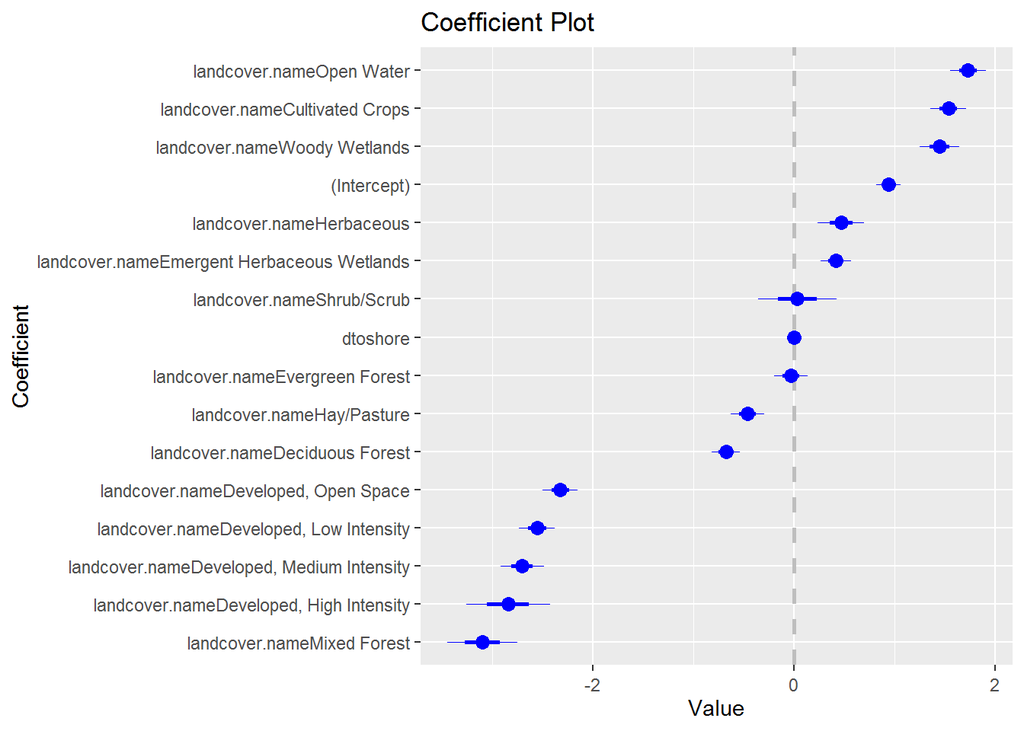

```r
require(coefplot)
coefplot(duck.fit, sort = "magnitude")
```

# 3. Cross-validation

split data up into test & training

```r
# 5-fold validation

n <- nrow(ducks.rsf)
k <- 5

training <- sample(1:n)[1:(round(n*(1-1/k)))]
test <- (1:n)[! (1:n) %in% training]

ducks_training <- ducks.rsf[training,]
ducks_test <- ducks.rsf[test,]
```

fit model with training set;

```r
duck.fit.training <- glm(Used ~ landcover.name +
                  dtoshore, family = "binomial", data = ducks_training)
```

predict to the test (out of sample) set:

```r
nbins <- 10
duck.predict.test  <- predict(duck.fit.training, newdata = ducks_test)
predict.quantiles <- quantile(duck.predict.test, seq(0,1, length = nbins+1), na.rm = TRUE)

predict.matrix <- as.matrix(table(ducks_test$Used, cut(duck.predict.test, predict.quantiles)))

p.present <- apply(predict.matrix, 2, function(x) x[2]/sum(x))
cv.score <- cor(1:nbins, p.present, method = "spearman")
```

High cross-validation score!

```r
cv.score
```

```
## [1] 0.984807
```

A function in the `[IndRSA](https://github.com/BastilleRousseau/IndRSA)` package does all of these things. Package not on CRAN, needs to be installed via:

```r
library(devtools)
install_github("BastilleRousseau/IndRSA")
```

```r
require(IndRSA)
duck_kfold <- kfoldRSF(duck.fit)
duck_kfold
```

```
##          kfold type
## 1   0.95099183  obs
## 2   0.98780442  obs
## 3   0.96326270  obs
## 4   0.98780442  obs
## 5   0.98780442  obs
## 6   0.95733487  obs
## 7   0.96609178  obs
## 8   0.98480698  obs
## 9   0.98780442  obs
## 10  0.99392092  obs
## 11 -0.34545455 rand
## 12 -0.09090909 rand
## 13  0.36474333 rand
## 14  0.53939394 rand
## 15 -0.01818182 rand
## 16 -0.16363636 rand
## 17 -0.44242424 rand
## 18 -0.03647433 rand
## 19 -0.27272727 rand
## 20  0.04242424 rand
```

# 4. Mapping

To map we need to *predict* across our rasters.

## Fit a model

The model has to be with “landcover” (not landcover name as above)

```r
duck.fit <- glm(Used ~ factor(landcover) +
                  dtoshore, family = "binomial", data = ducks.rsf)
```

## Create a prediction data frame from raster

Now we need to make a data frame of ALL the raster values in the covariate stack.

```r
allcovars.df <- terra::as.data.frame(habitat, na.rm = FALSE)
```

## Predict model for new data frame

Now we “predict” the model over this stack. Except this will give an error.

```r
duck.predict.values <- predict(duck.fit, newdata = allcovars.df)
```

```
Error in model.frame.default(Terms, newdata, na.action = na.action, xlev = object$xlevels) :
  factor factor(landcover) has new levels 0
```

Why? because there are “zeros” in the landcover data that are not in the duck data. We need to remove them from the prediction data frame.

```r
allcovars.df$landcover[allcovars.df$landcover == 0] <- NA
duck.predict.values <- predict(duck.fit, newdata = allcovars.df)
```

Prep a raster, identical in structure to the original habitat rasters:

```r
duck.predict.raster <- habitat[[1]]
```

## Create new raster of predictions

Fill that raster with the prediction values:

```r
values(duck.predict.raster) <- duck.predict.values
```

## Simple map

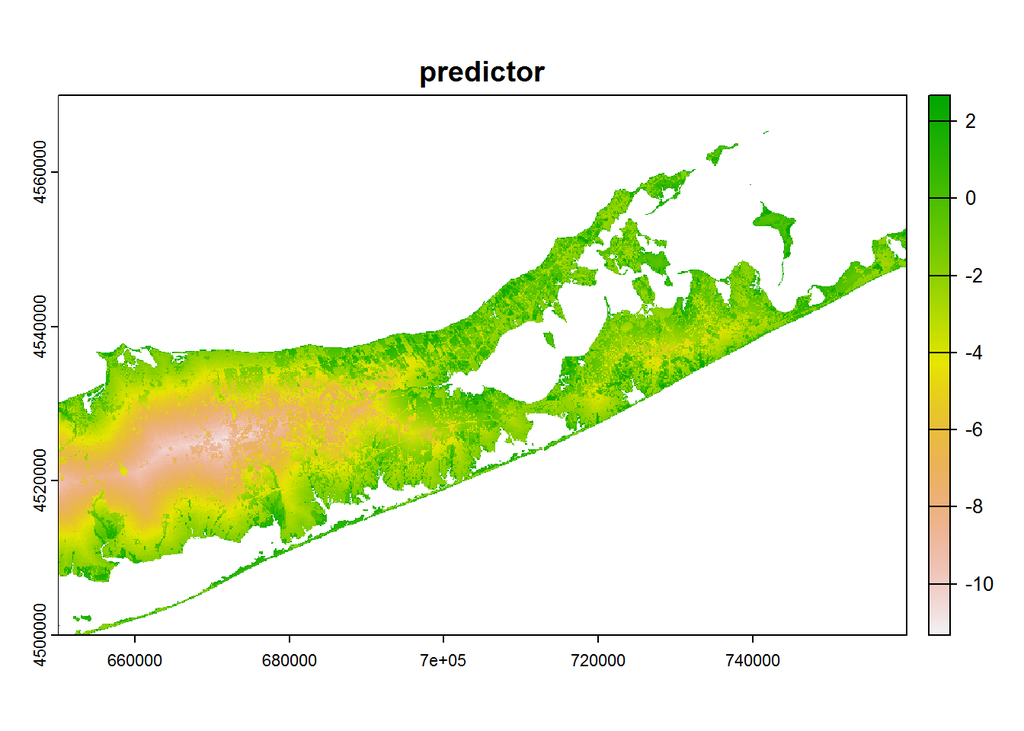

```r
plot(duck.predict.raster, main = "predictor")
```

```r
require(rasterVis)
```

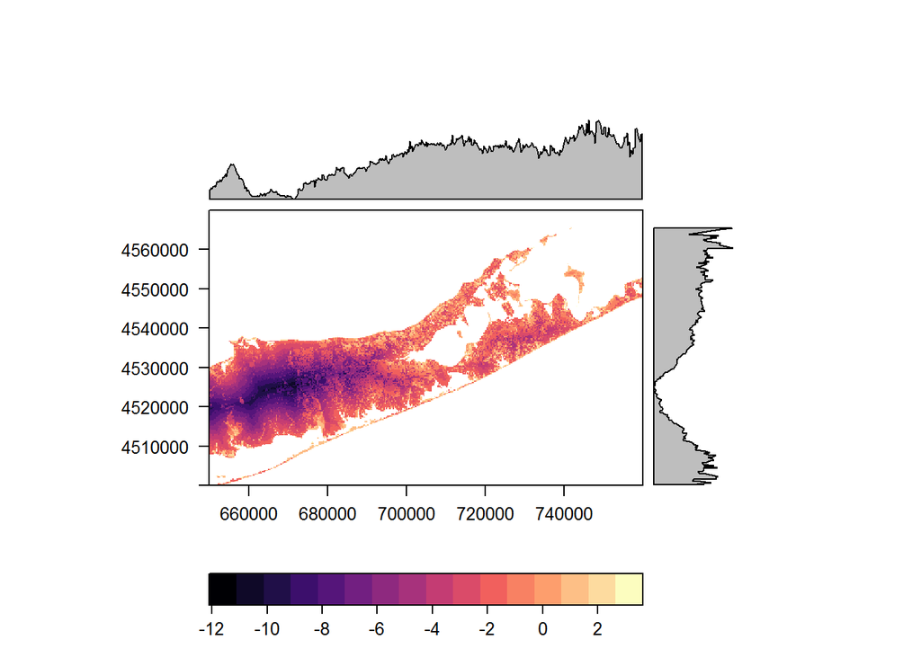

```r
levelplot(duck.predict.raster)
```

Or back-transform to probabilities?

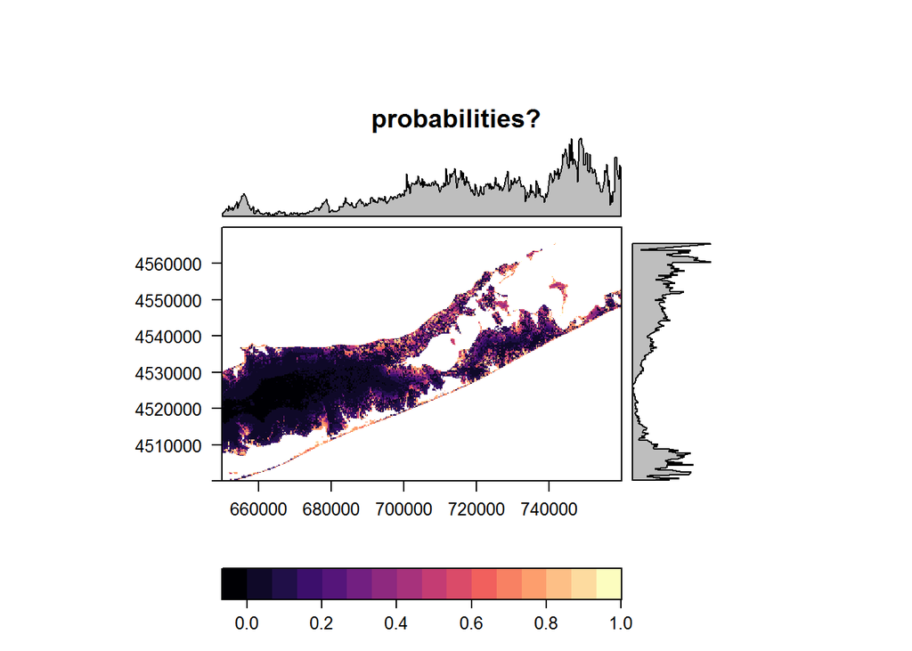

```r
levelplot(exp(duck.predict.raster)/(1+exp(duck.predict.raster)), main = "probabilities?")
```

Or w(x) rsf function?

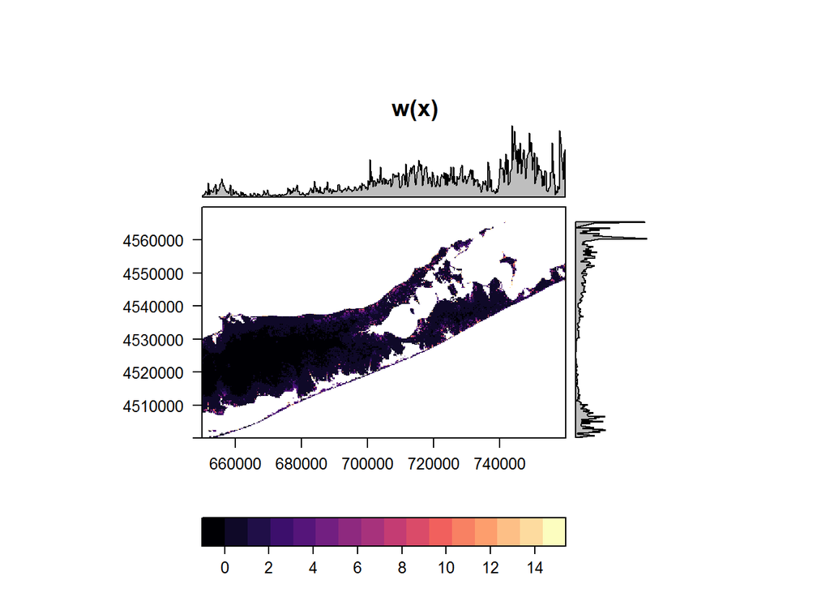

```r
levelplot(exp(duck.predict.raster), main = "w(x)")
```

These are NOT very helpful!

## Equal area bins

This is what Morris likes best of all Key functions: `cut` and `quantile`

```r
n.bins <- 10
breaks <- quantile(duck.predict.values, seq(0,1,length = n.bins + 1), na.rm = TRUE)
duck.predict.binned <- cut(duck.predict.values, breaks)

duck.predict.raster.binned <- duck.predict.raster
values(duck.predict.raster.binned) <- duck.predict.binned
```

Here’s a plot using my favorite high-contrast color palette:

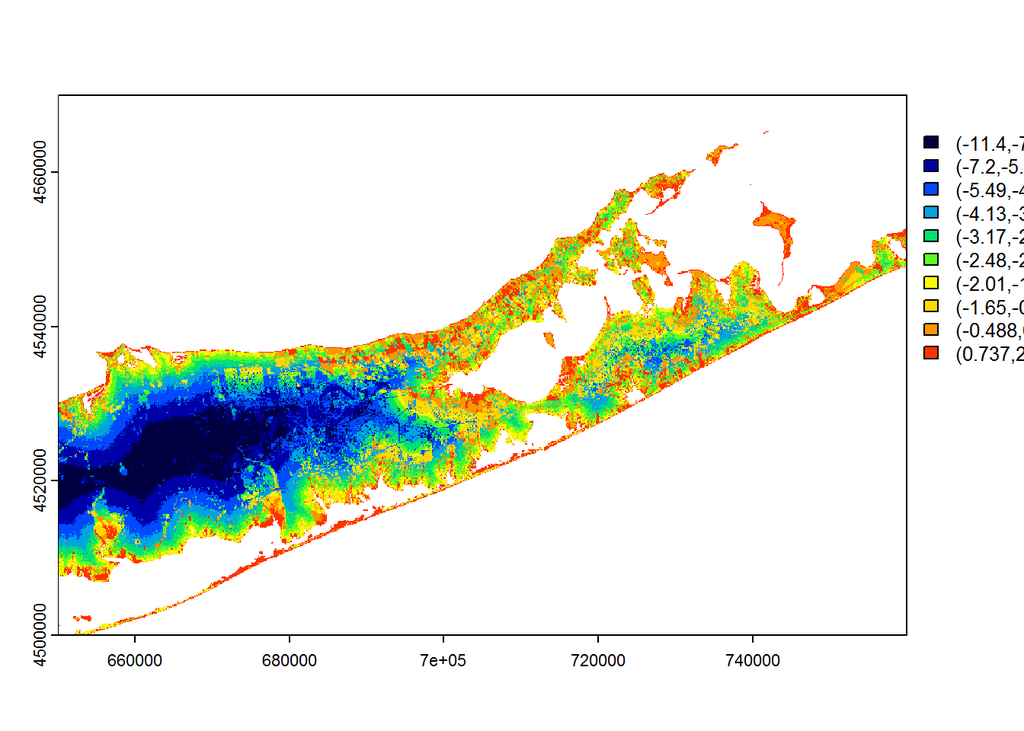

```r
require(gplots)
plot(duck.predict.raster.binned, col = rich.colors(n.bins))
```

## Bundling things into a function

can be super useful:

```r
getBinnedRaster  <- function(duck.model, n.bins){

  duck.predict.values <- predict(duck.model, newdata = allcovars.df)
  breaks <- quantile(duck.predict.values, seq(0,1,length = n.bins + 1), na.rm = TRUE)
  duck.predict.binned <- cut(duck.predict.values, breaks)
  duck.predict.raster.binned <- duck.predict.raster

  values(duck.predict.raster.binned) <- duck.predict.binned
  return(duck.predict.raster.binned)
}
```

Test function on what we made:

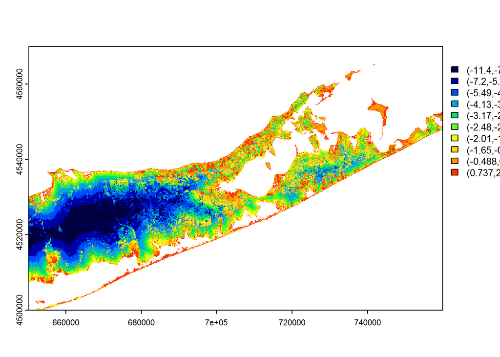

```r
r1 <- getBinnedRaster(duck.fit, 10)
plot(r1,  col = rich.colors(10))
```

Try a different model, e.g. with second order distance to shore:

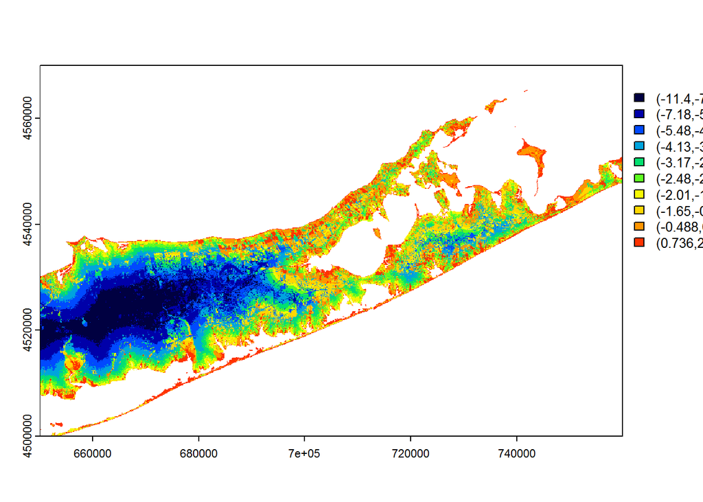

```r
duck.fit2 <- glm(Used ~ factor(landcover) + dtoshore + I(dtoshore^2),
                 family = "binomial", data = ducks.rsf)
r2 <- getBinnedRaster(duck.fit2, 10)
plot(r2,  col = rich.colors(10))
```

Try a model:

```r
require(lubridate)
duck.fit.midday <- glm(Used ~ factor(landcover) + dtoshore,
                 family = "binomial", data = ducks.rsf %>%
                   subset(hour(datetime) > 9 & hour(datetime) < 15 | Used == FALSE))

duck.fit.midnight <- glm(Used ~ factor(landcover) + dtoshore,
                 family = "binomial", data = ducks.rsf %>%
                   subset(hour(datetime) > 21 | hour(datetime) < 3 | Used == FALSE))

r.midday <- getBinnedRaster(duck.fit.midday, 10)
r.midnight <- getBinnedRaster(duck.fit.midnight, 10)
```

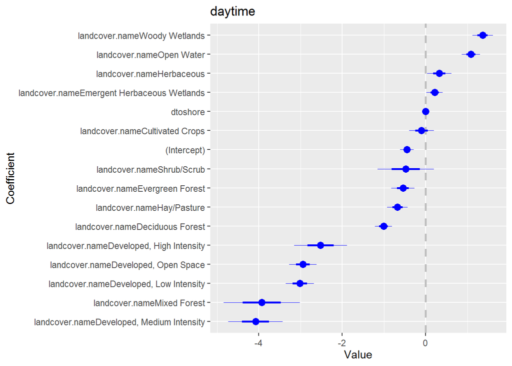

```r
glm(Used ~ landcover.name + dtoshore,
                 family = "binomial", data = ducks.rsf %>%
                   subset(hour(datetime) > 9 & hour(datetime) < 15 | Used == FALSE)) %>%
  coefplot(sort = "magnitude", title = "daytime")
```

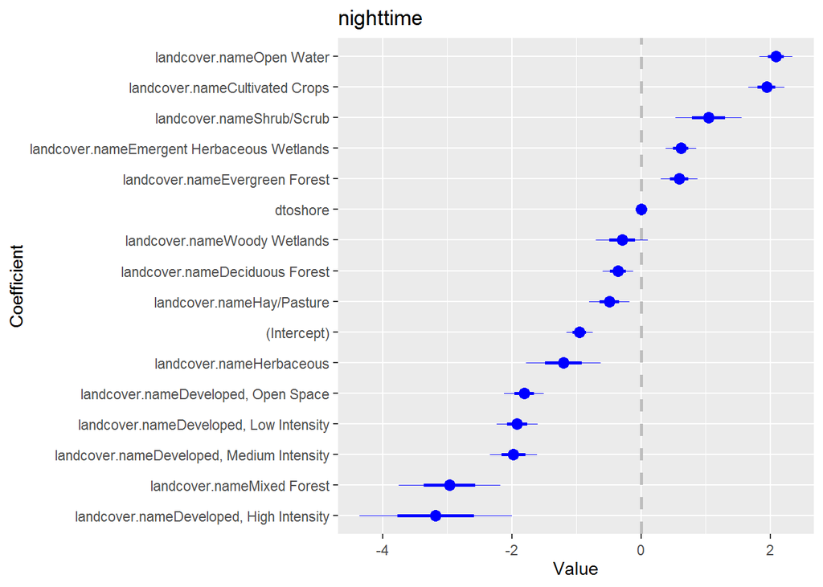

```r
glm(Used ~ landcover.name + dtoshore,
                 family = "binomial", data = ducks.rsf %>%
                   subset(hour(datetime) > 21 | hour(datetime) < 3 | Used == FALSE))%>%
  coefplot(sort = "magnitude", title = "nighttime")
```

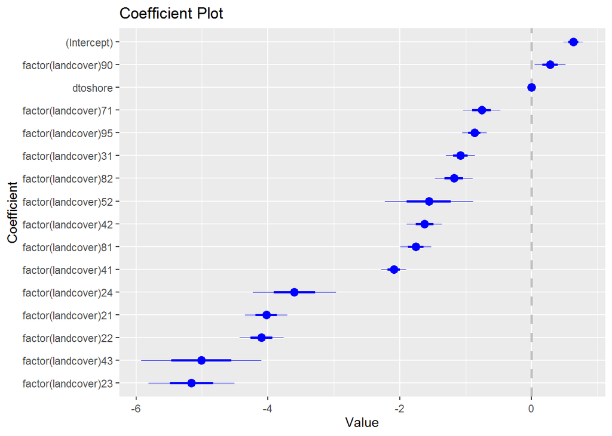

```r
coefplot(duck.fit.midday, sort = "magnitude")
```

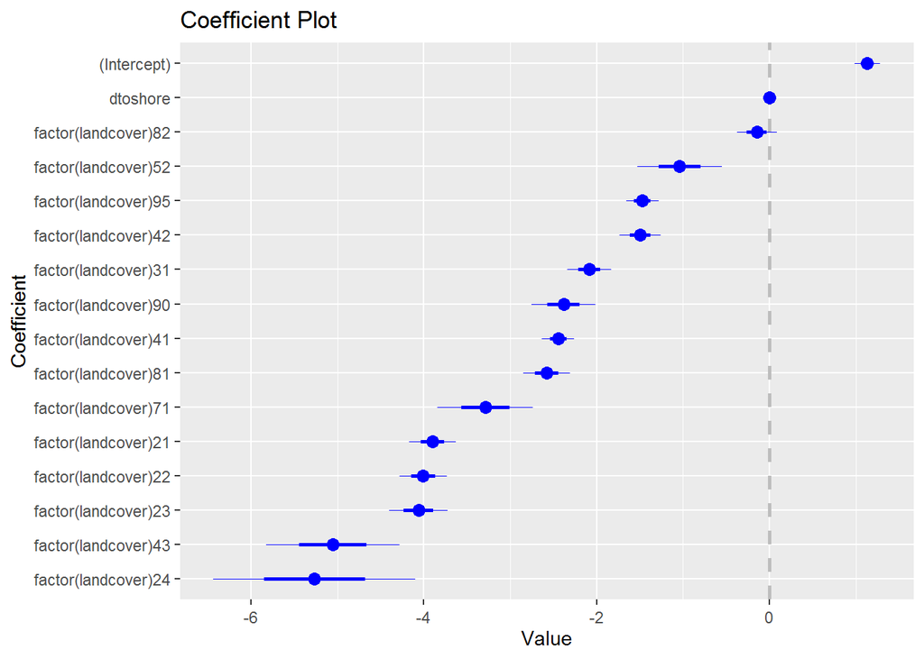

```r
coefplot(duck.fit.midnight, sort = "magnitude")
```

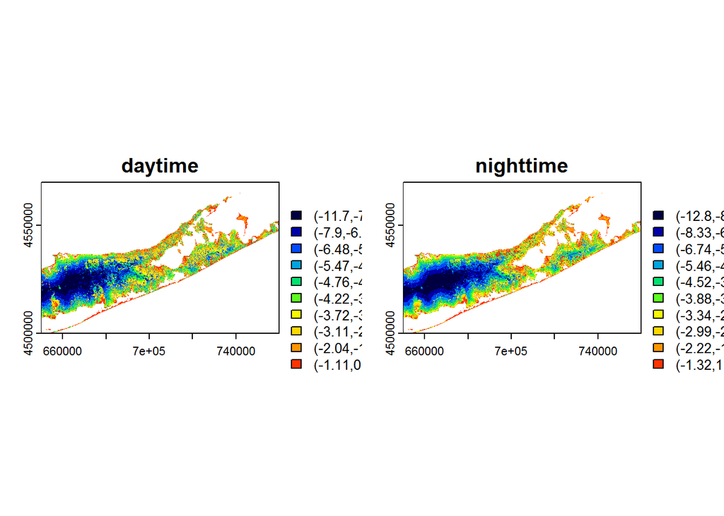

```r
par(mfrow = c(1,2))
plot(r.midday,  col = rich.colors(10), main = "daytime")
plot(r.midnight,  col = rich.colors(10), main = "nighttime")
```